# stock_price_analysis03

# Stock Prices Analysis

Continue with part 1 …

```r
library(tseries)
library(forecast)
```

## Exercise 1

Test for normality of the distribution of closing prices of YHOO using histogram.

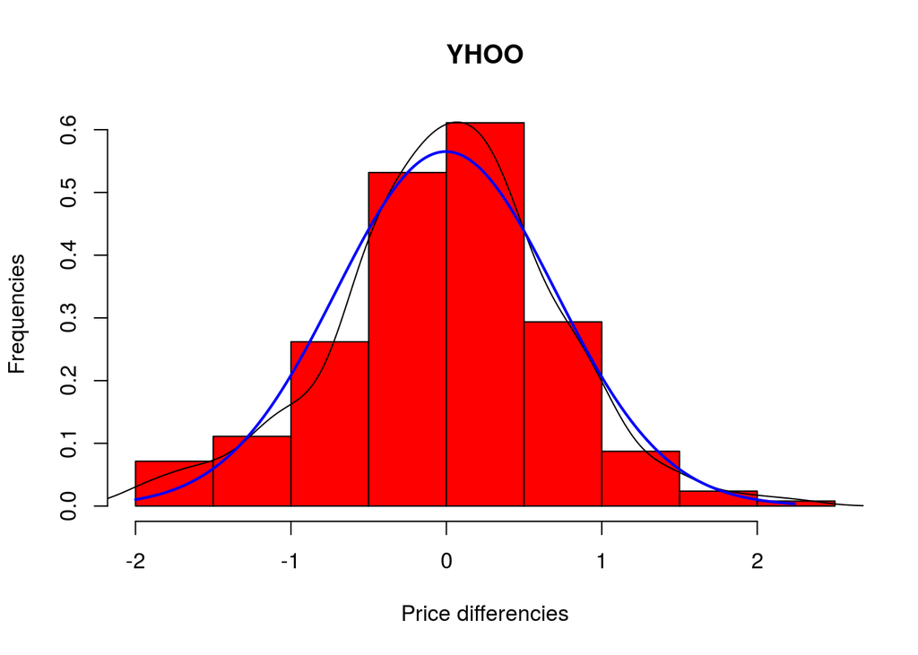

```r
data <- read.csv("http://www.r-exercises.com/wp-content/uploads/2016/07/data.csv")
data.close <- reshape(data[c("Symbol","Date","Close")], timevar="Symbol", idvar="Date", direction="wide")
colnames(data.close) <- c("Date", as.character(unique(data$Symbol)))
data.close$Date <- as.Date(data.close$Date)
data.close <- data.close[with(data.close, order(Date)), ]

diff.yhoo <- diff(data.close$YHOO)

hist(diff.yhoo, prob="T", col="red", ylab="Frequencies", xlab="Price differencies", main="YHOO")
lines(density(diff.yhoo))
mu <- mean(diff.yhoo)
sigma <- sd(diff.yhoo)
x <- seq(min(diff.yhoo), max(diff.yhoo), length=length(diff.yhoo))
y <- dnorm(x, mu, sigma)
lines(x, y, lwd=2, col="blue")
```

## Exercise 2

Test for normality of the distribution of closing prices of YHOO using normal q-q plot.

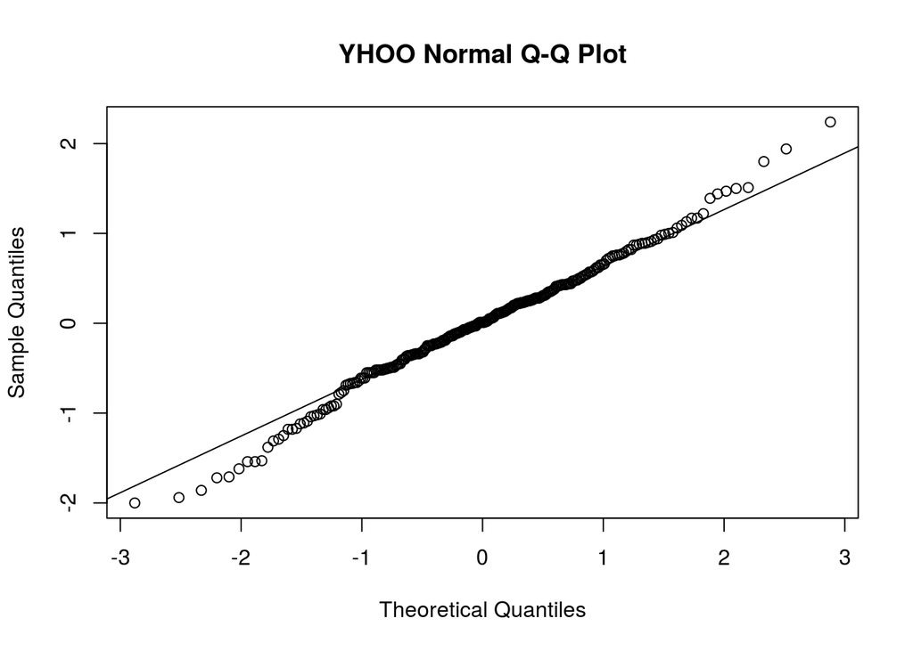

```r
qqnorm(diff.yhoo, main="YHOO Normal Q-Q Plot")
qqline(diff.yhoo)
```

## Exercise 3

Test for normality of distribution of closing prices of YHOO using Kolmogorov-Smirnov and Shapiro tests.

Based on four tests, what can you say about the closing prices of YHOO?

1. Closing prices of YHOO are approximately normaly distributed
2. The distribution of closing prices of YHOO does not conform to the normal distribution

```r
ks.test(diff.yhoo, "pnorm", mean(diff.yhoo), sd(diff.yhoo))
```

```
##
##  One-sample Kolmogorov-Smirnov test
##
## data:  diff.yhoo
## D = 0.052668, p-value = 0.4867
## alternative hypothesis: two-sided
```

```r
shapiro.test(diff.yhoo)
```

```
##
##  Shapiro-Wilk normality test
##
## data:  diff.yhoo
## W = 0.99146, p-value = 0.1503
```

## Exercise 4

Plot on the same chart:

1. Closing prices of GE
2. 12 days moving average of the closing prices of GE
3. 50 days moving average of the closing prices of GE

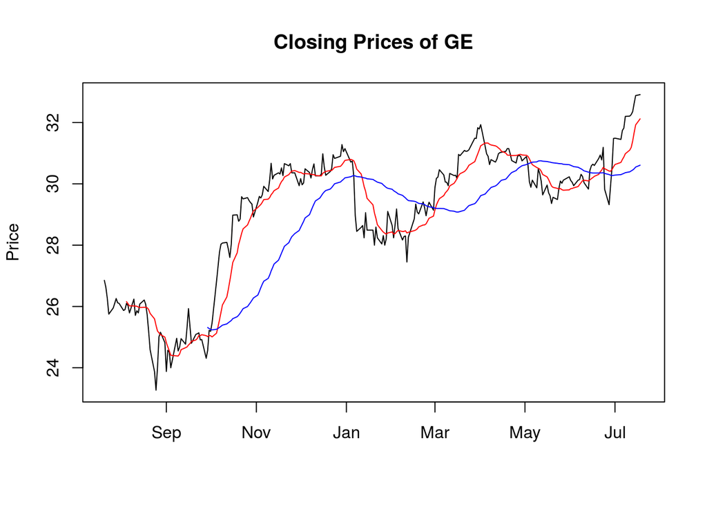

```r
plot(x=data.close$Date, y=data.close$GE, type='l', main="Closing Prices of GE", xlab="", ylab="Price")
lines(x=data.close$Date, y=filter(data.close$GE, filter=rep(1/12, 12), method="convolution", sides=1), col="red")
lines(x=data.close$Date, y=filter(data.close$GE, filter=rep(1/50, 50), method = "convolution", sides = 1), col="blue")
```

## Exercise 5

Create ts object and display closing prices of BAC on correliogram. Is the time series stationary?

- Yes
- No

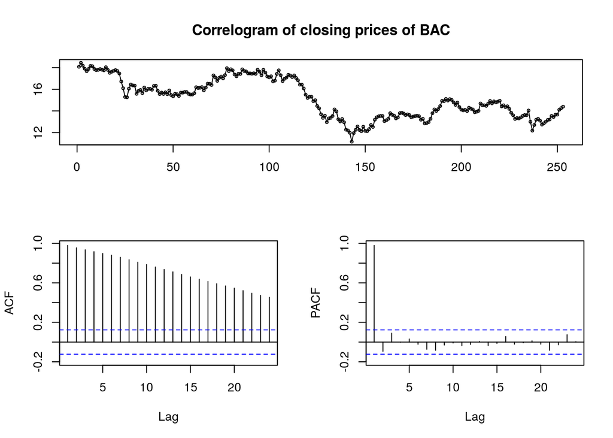

```r
data.close.ts <- ts(data.close[, -1])
tsdisplay(data.close.ts[, "BAC"], main="Correlogram of closing prices of BAC")
```

## Exercise 6

Is the time series of the closing prices of BAC stationary when you differentiate it, based on the correliogram?

- Yes
- No

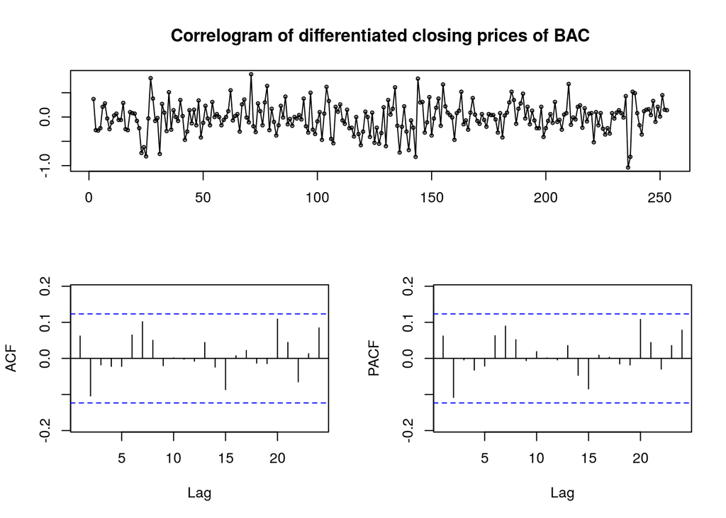

```r
tsdisplay(diff(data.close.ts[, "BAC"]), main="Correlogram of differentiated closing prices of BAC")
```

## Exercise 7

Find the best fitting ARIMA model for closing prices of BAC.

```r
fit.diff <- auto.arima(diff(data.close.ts[, "BAC"]), stepwise=FALSE)
summary(fit.diff)
```

```
## Series: diff(data.close.ts[, "BAC"])
## ARIMA(2,0,0) with zero mean
##
## Coefficients:
##          ar1      ar2
##       0.0719  -0.1065
## s.e.  0.0627   0.0627
##
## sigma^2 estimated as 0.09424:  log likelihood=-58.99
## AIC=123.97   AICc=124.07   BIC=134.56
##
## Training set error measures:
##                       ME      RMSE      MAE MPE MAPE     MASE         ACF1
## Training set -0.01518541 0.3057712 0.233653 NaN  Inf 0.709925 -0.003572584
```

## Exercise 8

Display ACF graph for the residuals of the model from exercise 7.

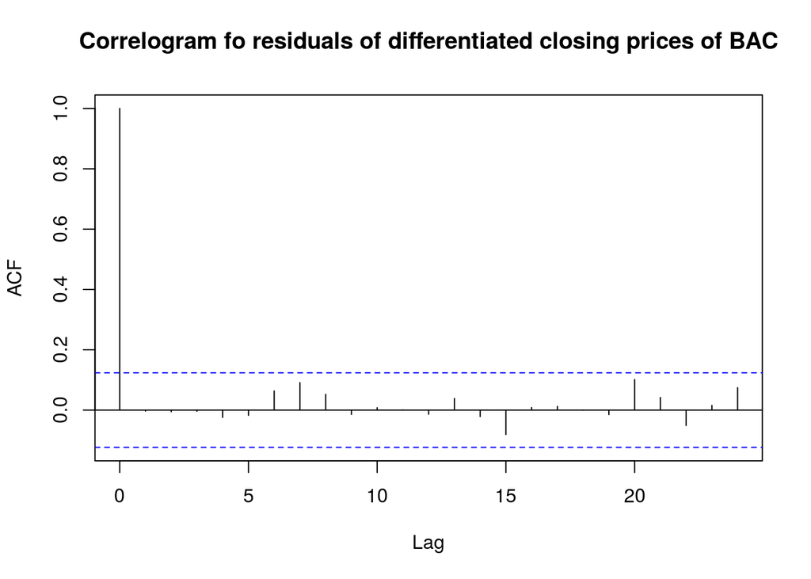

```r
acf(residuals(fit.diff), main="Correlogram fo residuals of differentiated closing prices of BAC")
```

## Exercise 9

Use the first 80% of a time series of prices of BAC to make a prediction for the rest 20% of data. Save the values in a variable.

```r
train <- data.close.ts[1:(0.8*length(data.close.ts[,"BAC"]))]
predictions <- predict(arima(train, order=c(2,0,0)), n.ahead=c(0.2*length(data.close.ts[, "BAC"])))$pred
```

## Exercise 10

Using data the exercise 9 and function accuracy from the forecast package, test the accuracy of the predictions. Is the prediction acceptable? (Tip: Prediction is acceptable if the field RMSE from the result of accuray is less than or equal to standard deviation of test data.).

```r
test <- data.close.ts[(0.8*length(data.close.ts[,"BAC"])+1):length(data.close.ts[,"BAC"])]
ac <- accuracy(predictions, test)[2]
stdev <- sd(test)

ifelse(ac <= stdev, "Yes", "No")
```

```
## [1] "No"
```